# Boulder DataScience as a field Final

LHE74

2022-08-13

## Introduction

This analysis is conducted as the final exam of the “Data Science as a Field” course held by the University of Boulder Colorado within the Master Ofr Data Science. Data are Covid 19 death and confirmed cases taken from Johns Hopkins University Github.

## R library upload

as a starting point to this analysis, let’s upload the packages that will be needed

```r
library(readr)
library(dplyr)
library(tidyr)
library(stringr)
library(lubridate)
library (ggplot2)
library(curl)
library(data.table)
library(forcats)
library (tinytex)
```

We will conduct an analysis of Covid data in the US based on the data from the CSSE at Johns Hopkins University. Data source is the CSSE github. We will consider the US confirmed and death cases only

```r
url_conf_us <- "https://raw.githubusercontent.com/CSSEGISandData/COVID-19/master/csse_covid_19_data/csse_covid_19_time_series/time_series_covid19_confirmed_US.csv"
url_death_us <- "https://raw.githubusercontent.com/CSSEGISandData/COVID-19/master/csse_covid_19_data/csse_covid_19_time_series/time_series_covid19_deaths_US.csv"
data_conf_us <- read_csv(url_conf_us)
data_death_us <- read_csv(url_death_us)
```

Let’s give a quick look at the data sets with the first rows

```r
head(data_conf_us)
```

```
## # A tibble: 6 x 945
##        UID iso2  iso3  code3  FIPS Admin2  Provinc~1 Count~2   Lat Long_ Combi~3
##      <dbl> <chr> <chr> <dbl> <dbl> <chr>   <chr>     <chr>   <dbl> <dbl> <chr>
## 1 84001001 US    USA     840  1001 Autauga Alabama   US       32.5 -86.6 Autaug~
## 2 84001003 US    USA     840  1003 Baldwin Alabama   US       30.7 -87.7 Baldwi~
## 3 84001005 US    USA     840  1005 Barbour Alabama   US       31.9 -85.4 Barbou~
## 4 84001007 US    USA     840  1007 Bibb    Alabama   US       33.0 -87.1 Bibb, ~
## 5 84001009 US    USA     840  1009 Blount  Alabama   US       34.0 -86.6 Blount~
## 6 84001011 US    USA     840  1011 Bullock Alabama   US       32.1 -85.7 Bulloc~
## # ... with 934 more variables: `1/22/20` <dbl>, `1/23/20` <dbl>,
## #   `1/24/20` <dbl>, `1/25/20` <dbl>, `1/26/20` <dbl>, `1/27/20` <dbl>,
## #   `1/28/20` <dbl>, `1/29/20` <dbl>, `1/30/20` <dbl>, `1/31/20` <dbl>,
## #   `2/1/20` <dbl>, `2/2/20` <dbl>, `2/3/20` <dbl>, `2/4/20` <dbl>,
## #   `2/5/20` <dbl>, `2/6/20` <dbl>, `2/7/20` <dbl>, `2/8/20` <dbl>,
## #   `2/9/20` <dbl>, `2/10/20` <dbl>, `2/11/20` <dbl>, `2/12/20` <dbl>,
## #   `2/13/20` <dbl>, `2/14/20` <dbl>, `2/15/20` <dbl>, `2/16/20` <dbl>, ...
## # i Use `colnames()` to see all variable names
```

```r
head(data_death_us)
```

```
## # A tibble: 6 x 946
##        UID iso2  iso3  code3  FIPS Admin2  Provinc~1 Count~2   Lat Long_ Combi~3
##      <dbl> <chr> <chr> <dbl> <dbl> <chr>   <chr>     <chr>   <dbl> <dbl> <chr>
## 1 84001001 US    USA     840  1001 Autauga Alabama   US       32.5 -86.6 Autaug~
## 2 84001003 US    USA     840  1003 Baldwin Alabama   US       30.7 -87.7 Baldwi~
## 3 84001005 US    USA     840  1005 Barbour Alabama   US       31.9 -85.4 Barbou~
## 4 84001007 US    USA     840  1007 Bibb    Alabama   US       33.0 -87.1 Bibb, ~
## 5 84001009 US    USA     840  1009 Blount  Alabama   US       34.0 -86.6 Blount~
## 6 84001011 US    USA     840  1011 Bullock Alabama   US       32.1 -85.7 Bulloc~
## # ... with 935 more variables: Population <dbl>, `1/22/20` <dbl>,
## #   `1/23/20` <dbl>, `1/24/20` <dbl>, `1/25/20` <dbl>, `1/26/20` <dbl>,
## #   `1/27/20` <dbl>, `1/28/20` <dbl>, `1/29/20` <dbl>, `1/30/20` <dbl>,
## #   `1/31/20` <dbl>, `2/1/20` <dbl>, `2/2/20` <dbl>, `2/3/20` <dbl>,
## #   `2/4/20` <dbl>, `2/5/20` <dbl>, `2/6/20` <dbl>, `2/7/20` <dbl>,
## #   `2/8/20` <dbl>, `2/9/20` <dbl>, `2/10/20` <dbl>, `2/11/20` <dbl>,
## #   `2/12/20` <dbl>, `2/13/20` <dbl>, `2/14/20` <dbl>, `2/15/20` <dbl>, ...
## # i Use `colnames()` to see all variable names
```

we can clearly see that the dates are not conveniently formatted for an analysis and that a pivot will be needed, we can also consider that some fields will be less relevant for us. like long/lat or UID.

## Data pivoting

We want to transform the date columns into a single column, using the pivot_longer function. the new field called “Date” will then contains the pivoted dates the new field called “Cases” will contain the occurrences

```r
data_conf_us_pivot <- data_conf_us %>%
  pivot_longer(cols = -c ("UID","iso2","iso3", "code3" ,"FIPS", "Admin2","Province_State","Country_Region","Lat","Long_", "Combined_Key"),
               names_to = "Date",
               values_to = "Cases" ) %>%
  ## ensure date formatting
      mutate (Conf_dt = mdy(Date))%>%
        group_by (Province_State,Conf_dt)%>%
          summarise (Conf_nb = sum (Cases))%>%
  ## keep only relevant fields
            select (c("Province_State","Conf_dt","Conf_nb"))

tail(data_conf_us_pivot)
```

```
## # A tibble: 6 x 3
## # Groups:   Province_State [1]
##   Province_State Conf_dt    Conf_nb
##   <chr>          <date>       <dbl>
## 1 Wyoming        2022-08-07  171322
## 2 Wyoming        2022-08-08  171322
## 3 Wyoming        2022-08-09  172473
## 4 Wyoming        2022-08-10  172473
## 5 Wyoming        2022-08-11  172473
## 6 Wyoming        2022-08-12  172473
```

We then now have the cumulative number of confirmed cases by state and date Let’s do the same thing for the death cases

```r
data_death_us_pivot <- data_death_us %>%

  pivot_longer(cols = -c ("UID","iso2","iso3", "code3" ,"FIPS", "Admin2","Province_State","Country_Region","Lat","Long_", "Combined_Key","Population"),
               names_to = "date",
               values_to = "cases" ) %>%
    mutate (cases = cases*1)%>%
    mutate (Population = Population*1)%>%
    mutate (Death_dt = mdy(date))%>%

    group_by(Province_State,Death_dt) %>%
    summarise(Death_nb = sum (cases), Population_nb = sum (Population))%>%

  select (c("Province_State", "Population_nb", "Death_dt","Death_nb"))

tail(data_death_us_pivot)
```

```
## # A tibble: 6 x 4
## # Groups:   Province_State [1]
##   Province_State Population_nb Death_dt   Death_nb
##   <chr>                  <dbl> <date>        <dbl>
## 1 Wyoming               578759 2022-08-07     1856
## 2 Wyoming               578759 2022-08-08     1856
## 3 Wyoming               578759 2022-08-09     1865
## 4 Wyoming               578759 2022-08-10     1865
## 5 Wyoming               578759 2022-08-11     1865
## 6 Wyoming               578759 2022-08-12     1865
```

We complement our data discovery with the basic statistics of the data sets

```r
summary(data_conf_us_pivot)
```

```
##  Province_State        Conf_dt              Conf_nb
##  Length:54172       Min.   :2020-01-22   Min.   :       0
##  Class :character   1st Qu.:2020-09-11   1st Qu.:   17240
##  Mode  :character   Median :2021-05-02   Median :  193024
##                     Mean   :2021-05-02   Mean   :  611678
##                     3rd Qu.:2021-12-22   3rd Qu.:  739216
##                     Max.   :2022-08-12   Max.   :10901301
```

```r
summary(data_death_us_pivot)
```

```
##  Province_State     Population_nb         Death_dt             Death_nb
##  Length:54172       Min.   :       0   Min.   :2020-01-22   Min.   :    0
##  Class :character   1st Qu.: 1068778   1st Qu.:2020-09-11   1st Qu.:  351
##  Mode  :character   Median : 3660113   Median :2021-05-02   Median : 2894
##                     Mean   : 5739226   Mean   :2021-05-02   Mean   : 9005
##                     3rd Qu.: 6892503   3rd Qu.:2021-12-22   3rd Qu.:11165
##                     Max.   :39512223   Max.   :2022-08-12   Max.   :94119
```

In order to conduct our analysis, we need to join both data sets based of the common fields. We use an inner join to ensure perfect matching based of dates and states.

```r
data_joint_us <- data_death_us_pivot %>%
  ## inner join ensure having death and confirmed data for shared states & date
  inner_join(data_conf_us_pivot, by = c("Province_State"="Province_State", "Death_dt" = "Conf_dt" )) %>%
  ## just a renaming as this is a date and not death or confirmed date
  rename (Date = "Death_dt")
tail (data_joint_us)
```

```
## # A tibble: 6 x 5
## # Groups:   Province_State [1]
##   Province_State Population_nb Date       Death_nb Conf_nb
##   <chr>                  <dbl> <date>        <dbl>   <dbl>
## 1 Wyoming               578759 2022-08-07     1856  171322
## 2 Wyoming               578759 2022-08-08     1856  171322
## 3 Wyoming               578759 2022-08-09     1865  172473
## 4 Wyoming               578759 2022-08-10     1865  172473
## 5 Wyoming               578759 2022-08-11     1865  172473
## 6 Wyoming               578759 2022-08-12     1865  172473
```

## Analysis

We want to visualize the stats having the highest cumulated death numbers over the period as a first filter to our analysis

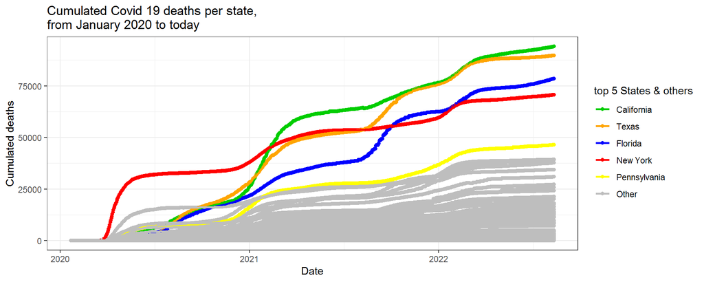

```r
## based on state we order the data
trend <- setDT(data_joint_us)[, Province_State := fct_reorder(Province_State, -Death_nb, last)]

## we individualize the top 5 and qualify them as Top_Province_State
trend[, Top_Province_State := fct_other(Province_State, keep = head(levels(Province_State), 5))]

## we trend the data, only coloring the top 5
ggplot(trend, aes(Date, Death_nb, group = Province_State, colour = Top_Province_State)) +
  geom_point() + geom_line(size = 1) + theme_bw() + ylab("Cumulated deaths") +
  scale_colour_manual(name = "top 5 States & others", values = c("green3", "orange", "blue", "red","yellow", "grey"))+
  ggtitle("Cumulated Covid 19 deaths per state,\nfrom January 2020 to today")
```

So we can clearly see which are the top 5 states in terms of absolute deaths and that despite a rapid start in New York this state is currently in 4th position when California has the opposite pattern, slow start then rapid growth to a sad pole position.

This cumulated chart is interesting but let’s see how each month behave for the top 4 states

```r
trend_data <- trend %>% filter (Province_State=="California"|Province_State=="Texas"| Province_State=="Florida"|
                                  Province_State=="New York"| Province_State=="Pennsylvania") %>%

##  compute the incremental based on cumulated numbers
      mutate_at(vars(Death_nb:Conf_nb),funs(.-c(0,lag(.)[-1]))) %>%

## simplify the date
       mutate (Incident_yr = year(Date),
            Incident_mnth = month(Date),
            ) %>%
      mutate(Date_short = make_date(Incident_yr, Incident_mnth, '01'))%>%

## summarize based on shorten date
      group_by (Province_State,Population_nb,Date_short) %>%
      summarise (Death_nb_mnth = round(sum (Death_nb),0), Conf_nb_mnth = round(sum (Conf_nb),0)) %>%

## reset first date to 0 death and 0 confirmed
      mutate(Death_nb_mnth=replace(Death_nb_mnth, Date_short=="2020-01-01", 0))%>%
      mutate(Conf_nb_mnth=replace(Conf_nb_mnth, Date_short=="2020-01-01", 0))
```

[figure not shown]

```r
## draw chart
trend_data %>%
   ggplot (aes(x = Date_short, y = Conf_nb_mnth))+
   geom_line (aes(color = Province_State)) + labs(x = "Dates") + labs(y = "Confirmed number of cases")+
   scale_colour_manual(name = "top 5 States", values = c("California" = "green3","Texas" = "orange",
                                                         "Florida" = "blue", "New York" = "red", "Pennsylvania" = "yellow")) +
  ggtitle("Incremental Covid 19 deaths for the top 5 states,\nfrom January 2020 to today")
```

To visualize that, we will display the difference between the death to confirmed case for the top 4 states vs the same rate for California. the top 3 state rate will be used as a 0 base and the deviation for California as a bar over or under this average.

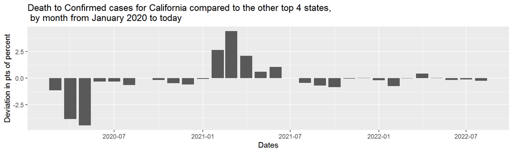

```r
## lets compute the rate for the other 3 states
total_rate <- trend_data %>% filter (Province_State != "California")%>%group_by (Date_short) %>% summarise (Death_nb_tot = sum (Death_nb_mnth), Conf_nb_tot = sum (Conf_nb_mnth)) %>%
  mutate (death_to_conf_rate_tot = Death_nb_tot/Conf_nb_tot)

## lets compute the rate for the California
total_calif <- trend_data %>% filter (Province_State == "California")%>%
  mutate (death_to_conf_rate_calif = Death_nb_mnth/Conf_nb_mnth)

## Joining the 2 data sets
Total_join <- total_rate %>%
  inner_join(total_calif, by = "Date_short") %>%
  select (Date_short,death_to_conf_rate_tot,death_to_conf_rate_calif) %>%
  mutate (Calif_dev = (death_to_conf_rate_calif- death_to_conf_rate_tot)*100)%>%
  select (Date_short,Calif_dev)
# tail (Total_join)

## display the deviation
Total_join %>%
   ggplot (aes(x = Date_short, y = Calif_dev))+
   geom_col() + labs(x = "Dates") + labs(y = "deviation")+
   labs(y = "Deviation in pts of percent") +
  ggtitle("Death to Confirmed cases for California compared to the other top 4 states,\n by month from January 2020 to today")
```

We visualize clearly that the death to confirm case rate for California, compared to the average rate of the the other top 4, is

- much lower before July 2020
- much higher between February and June 2021
- about at par for the rest of the period

November and December 2020 and 2021 are not especially higher than the other 4 states.

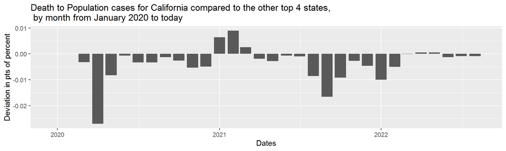

```r
## lets compute the rate for the other 3 states
total_death_rate <- trend_data %>% filter (Province_State != "California")%>%group_by (Date_short) %>% summarise (Death_nb_tot = sum (Death_nb_mnth), Population_tot = sum (Population_nb)) %>%
  mutate (death_pop_rate_tot = Death_nb_tot/Population_tot)

## lets compute the rate for the California
total_death_calif <- trend_data %>% filter (Province_State== "California")%>%
  mutate (death_pop_rate_calif = Death_nb_mnth/Population_nb)

## Joining the 2 data sets
Total_death_join <- total_death_rate %>%
  inner_join(total_death_calif, by = "Date_short") %>%
  select (Date_short,death_pop_rate_calif,death_pop_rate_tot) %>%
  mutate (Calif_death = (death_pop_rate_calif- death_pop_rate_tot)*100)%>%
  select (Date_short,Calif_death)
# tail (Total_join)

## display the deviation
Total_death_join %>%
   ggplot (aes(x = Date_short, y = Calif_death))+
   geom_col() + labs(x = "Dates") + labs(y = "deviation")+
  labs(y = "Deviation in pts of percent") +
  ggtitle("Death to Population cases for California compared to the other top 4 states,\n by month from January 2020 to today")
```

## Possible bias:

We have only considered the top 5 states to compare with the highest one of them, ie, California, which may hide other interesting patterns. We have considered only at total state level when an investigation within California provinces may also revel interesting patterns. Altogether, this is a very rapid and high level approach that would deserve much deeper investigations.